# Sesion 18 - Datos Categoricos y Modelos de Grafos Probabilisticos Parte 1/7

Juan Carlos Martínez-Ovando

Maestría en Ciencia de Datos

Primavera 2019

# 1 Objetivos

- Revisaremos la creacion de grafos en `R`, asi como algunas definiciones y propiedades fundamentales
- Realizaremos una inspeccion de algunos calculos de estadisticas basicas para modelos de grafos
- Emplearemos las librerias `diagram` e `igraph` de `R`:

En `R` podemos crear modelos graficos empleando las librerias `diagram` e `igraph`.

# 2 Creacion de diagramas con `diagram`

La libreria `diagram` permite crear grafos en `R`. Por **ejemplo**, creamos un grafo conectado con dos niveles donde los primeros 2 `nodos` comparten la misma línea y los 2 siguientes `nodos` comparten otro nivel de conectividad.

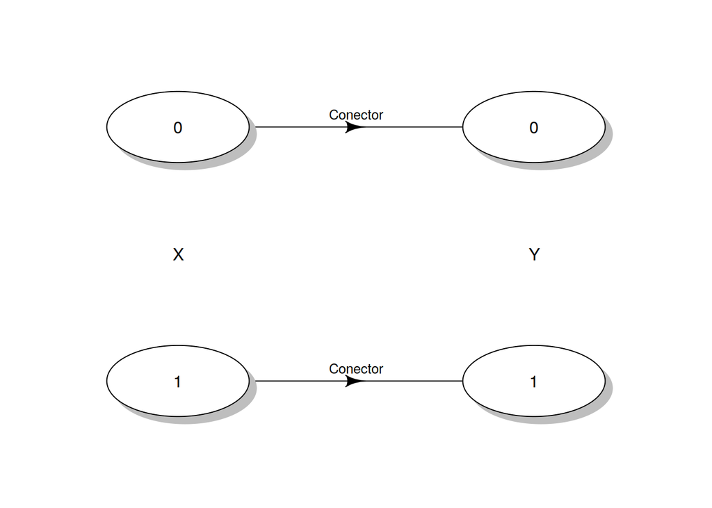

```r
names <- c("0", "0", "1", "1")
M <- matrix(nrow = 4, ncol = 4, byrow = TRUE, data = 0)
M[2, 1] <- M[4, 3] <- "Conector"

par(mar = c(0, 0, 0, 0))
plotmat(M, pos = c(2, 2),
           # pos - posicion del grafo
           name = names, lwd = 1, curve = 0,
           box.lwd = 1, cex.txt = 0.8, box.size = .1,
           box.type = "circle", box.prop = 0.5)
text(0.25,.5,"X"); text(.75,.5,"Y");
```

En este caso, `plotmat` indica las caracteristicas del grafo. En el siguiente **ejemplo**, `pos` especifica las coordenadas para cada `nodo` (dentro del cuadro $[(0,0), (1,1)])$.

```r
names <- c(# nivel 1
           "0", "1", "2",
           # Nivel 2
           "4", "5", "6")
M <- matrix(nrow = 6, ncol = 6, byrow = TRUE, data = 0)
# Etiquetas de los conectores
M[2, 1] <- "Conector_1"
M[3, 1] <- "Conector_2"
M[5, 4] <- "Conector_3"
M[6, 4] <- "Conector_4"
```

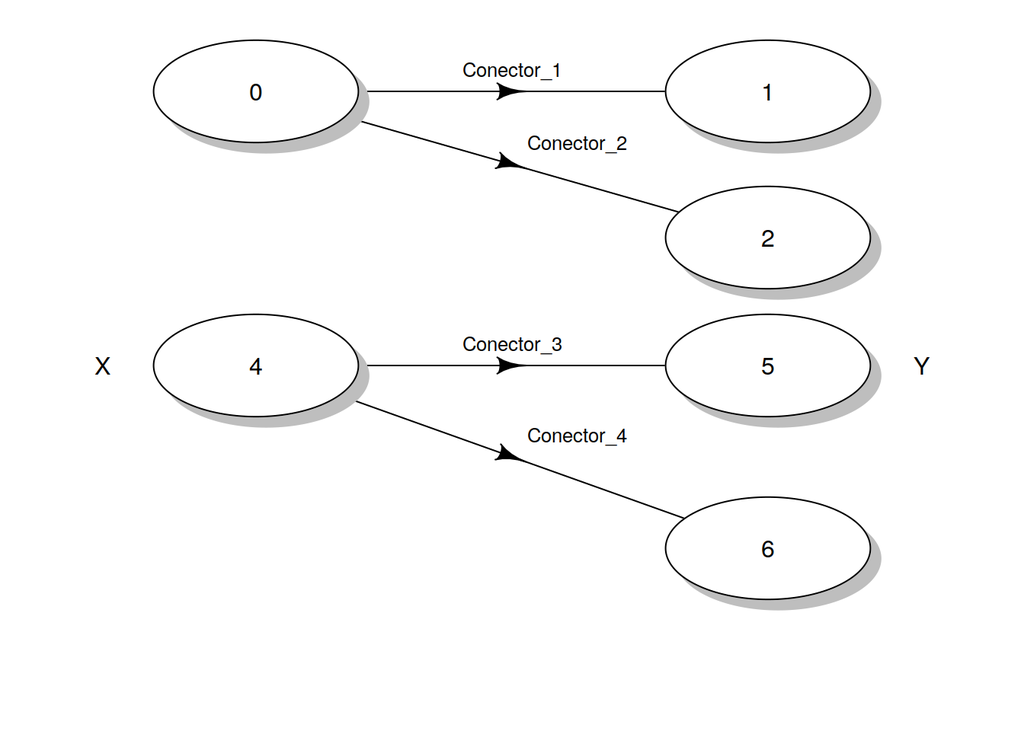

```r
par(mar = c(0, 0, 0, 0))
plotmat(M,
        pos = matrix(c(.25,.875, .75,.875, .75,.675, .25,.5, .75,.5, .75,.25),
                     ncol=2, byrow=TRUE),
        name = names, lwd = 1, curve = 0,
        box.lwd = 1, cex.txt = 0.8, box.size = .1,
        box.type = "circle", box.prop = 0.5)

# Etiquetas adicionales para ciertos nodos, marcando las coordenadas de inclusion
text(0.1,.5,"X")
text(.9,.5,"Y");
```

Ahora, en este **ejemplo** definiremos conectores cruzados en el `grafo`.

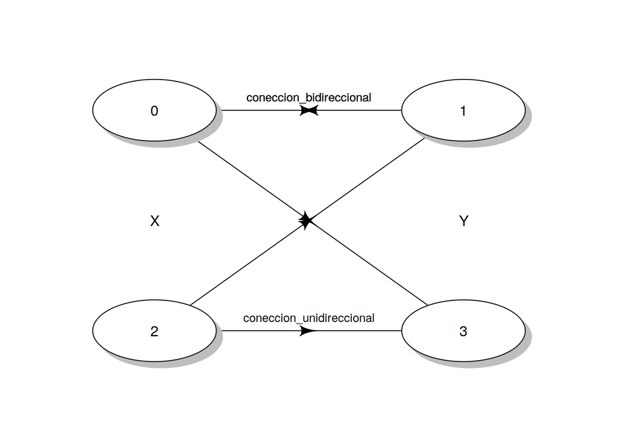

```r
names <- c(# nivel 1
           "0", "1",
           # nivel 2
           "2", "3")

M <- matrix(nrow = 4, ncol = 4, byrow = TRUE, data = 0)

# Relacion bidireccional en el primer nivel
M[2, 1] <- "coneccion_bidireccional"
M[1, 2] <- "coneccion_bidireccional"
M[4, 3] <- "coneccion_unidireccional"
M[4, 1] <- ""
M[2, 3] <- ""

par(mar = c(0, 0, 0, 0))
plotmat(M, pos = c(2, 2), name = names, lwd = 1, curve = 0,
           box.lwd = 1, cex.txt = 0.8, box.size = .1,
           box.type = "circle", box.prop = 0.5)
text(0.25,.5,"X")
text(.75,.5,"Y")
```

# 3 Creacion de diagramas con `igraph`

La libreria `igraph` es mucho mas flexible que `diagram`, como veremos a continuacion. Consideraremos varios ejemplos particulares.

## 3.1 E1:- `graph.ring`

`graph.ring` produce grafos superficiales. En este caso, tenemos como `primer argumento` al numero de `nodos`, como `segudo argumento` si es un grafo `dirigido`, y como `tercer argumento` si es un `simetrico`.

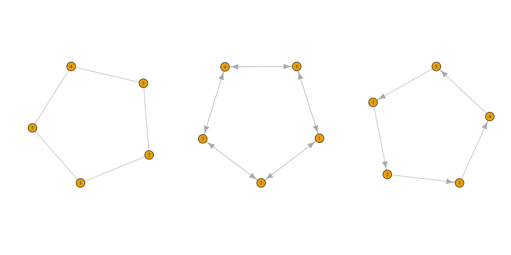

```r
library("igraph")

par(mfrow=c(1,3))
# grafo circular
plot(graph.ring(5,circular=TRUE))
# grafo dirigido simetrico
plot(graph.ring(5,directed=TRUE,mutual=TRUE))
# grafo dirigido asimetrico
plot(graph.ring(5,directed=TRUE,mutual=FALSE))
```

## 3.2 E2:- `graph.star`

`graph.star` produce grafos colindantes (o concentricos). En el `primer argumento` consideramos el numero de nodos (teniendo uno de ellos concentrico), en el `segundo argumento` especificamos la direccionalidad de las conexiones.

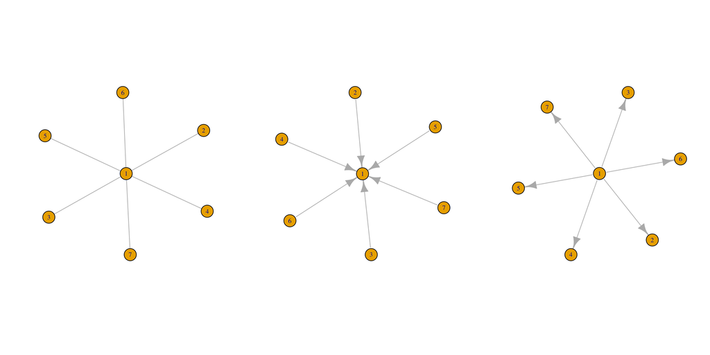

```r
par(mfrow=c(1,3))
# grafo no dirigido
plot(graph.star(7,mode="undirected"))
# grafo dirigido concentrico
plot(graph.star(7,mode="in"))
# grafo dirigido no concentrico
plot(graph.star(7,mode="out"))
```

## 3.3 E3:- `graph.lattice`

`graph.lattice` produce grafos concetores para un `grid` (o `cuadricula`) de `nodos`. La `cuadricula` se define como primer argumente, admitiendo grafos en multiples dimensiones con base en un `array`.

```r
# Definimos la cuadricula
graph.lattice( c(3,4) )
```

```
## IGRAPH 7ab63bd U--- 12 17 -- Lattice graph
## + attr: name (g/c), dimvector (g/n), nei (g/n), mutual (g/l),
## | circular (g/l)
## + edges from 7ab63bd:
##  [1]  1-- 2  1-- 4  2-- 3  2-- 5  3-- 6  4-- 5  4-- 7  5-- 6  5-- 8  6-- 9
## [11]  7-- 8  7--10  8-- 9  8--11  9--12 10--11 11--12
```

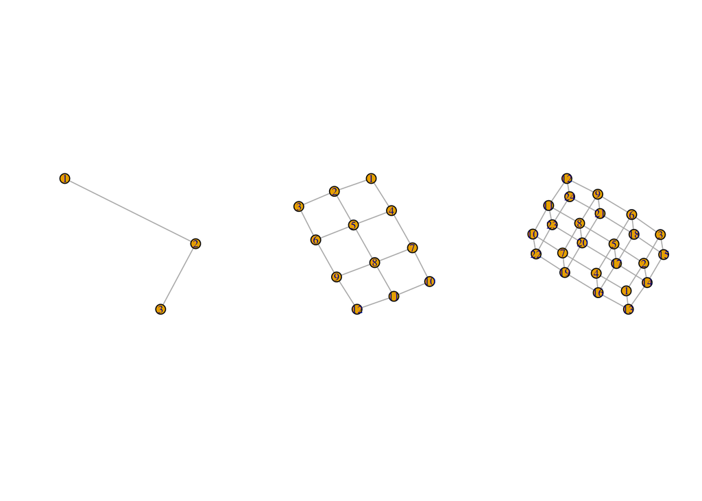

```r
par(mfrow=c(1,3))
# Grafo en una dimension
plot(graph.lattice( c(3) ))
# Grafo en dos dimensiones
plot(graph.lattice( c(3,4) ))
# Grafo en tres dimensiona
plot(graph.lattice( c(3,4,2) ))
```

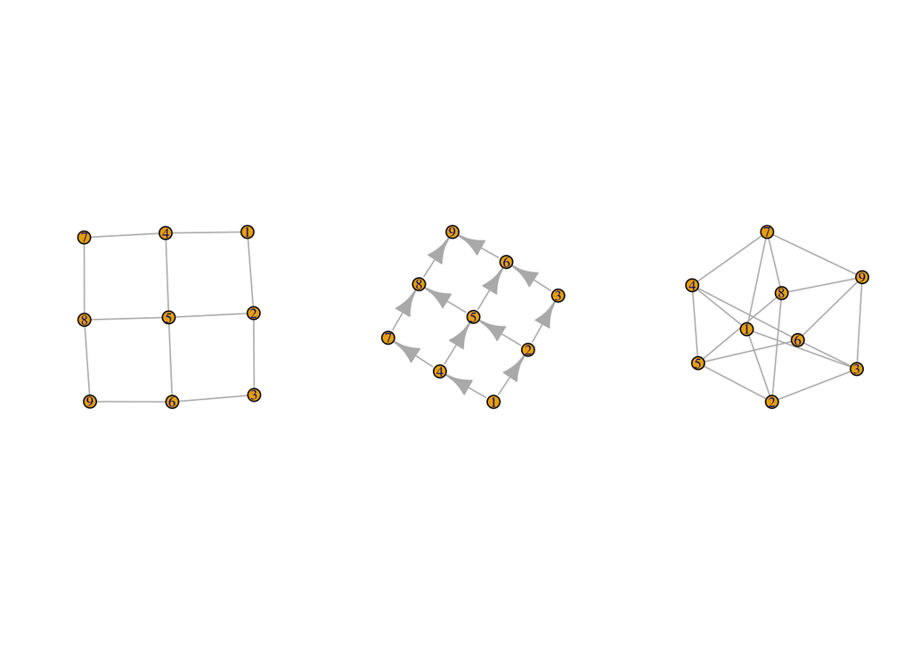

```r
par(mfrow=c(1,3))
# grafos sin conectividad dirigida
plot(graph.lattice( c(3,3) ))
# grafos con conectividad dirigida
plot(graph.lattice( c(3,3), directed=TRUE ))
# grafos con conectividad dirigida ciclica
plot(graph.lattice( c(3,3), circular=TRUE ))
```

## 3.4 E4:- `graph.tree`

Con `graph.tree` definimos grafos jerarquicos, donde la conectividad de los `nodos` esta especificada de manera `asimetrica`. Este tipo de `grafo` corresponde a un arbol de `descendencia dual` (i.e. arboles donde existen dos descendientes a lo mas) por cada `nodo`. El numero de `nodos` corresponde al primer argumento de la funcion.

```r
# Definimos un arbol
graph.tree(8)
```

```
## IGRAPH f83e1b0 D--- 8 7 -- Tree
## + attr: name (g/c), children (g/n), mode (g/c)
## + edges from f83e1b0:
## [1] 1->2 1->3 2->4 2->5 3->6 3->7 4->8
```

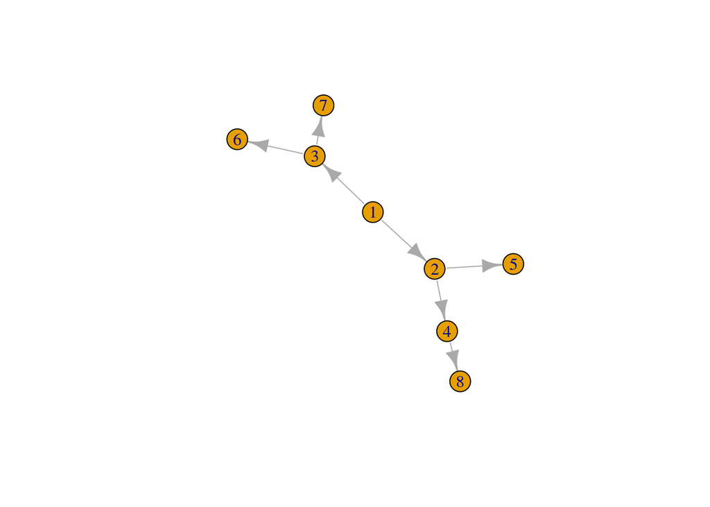

```r
plot(graph.tree(8))
```

El `segundo argumento` de la funcion corresponde al tipo de descendendencia (podemos especificar mas de `dos` descendientes por nodo).

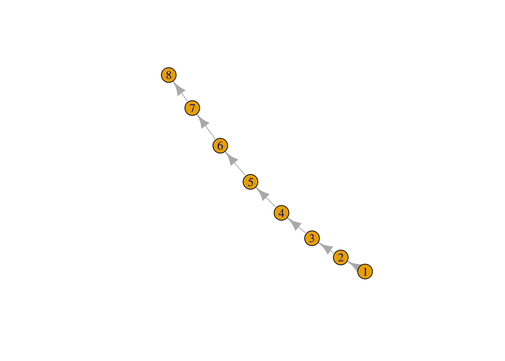

```r
par(mfrow=c(1,1))
# un descendiente
plot(graph.tree(8, children=1))
```

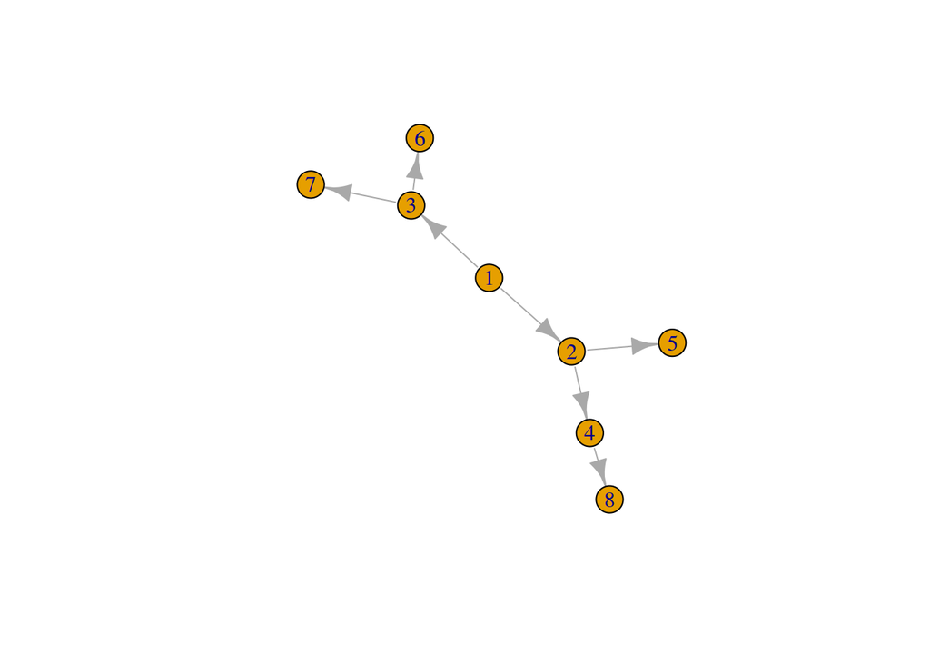

```r
# dos descendientes
plot(graph.tree(8, children=2))
```

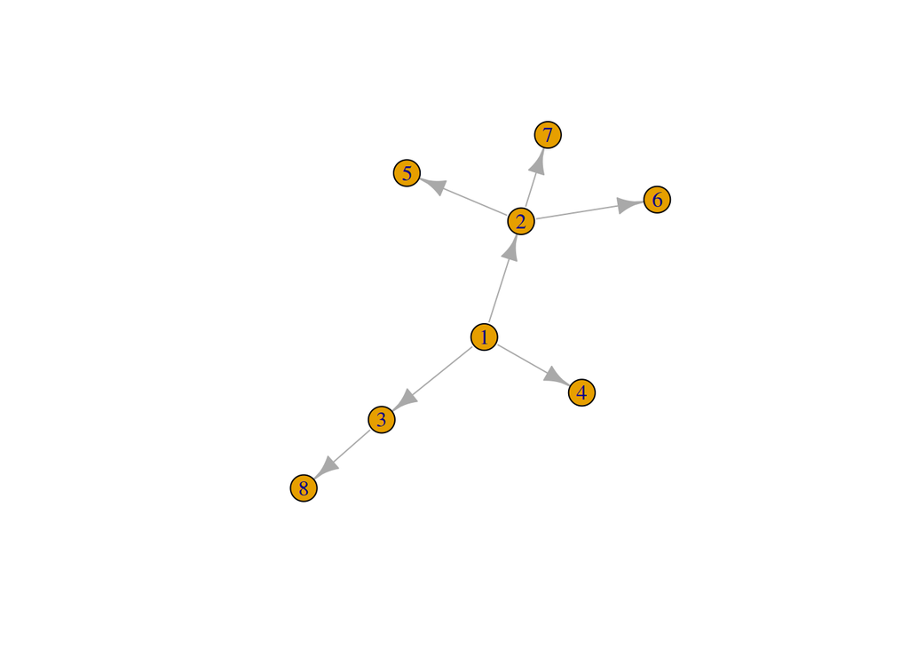

```r
# tres descendientes
plot(graph.tree(8, children=3))
```

El `tercer argumento` consiste en la conectividad de los `nodos descendientes` con su `nodo origen`.

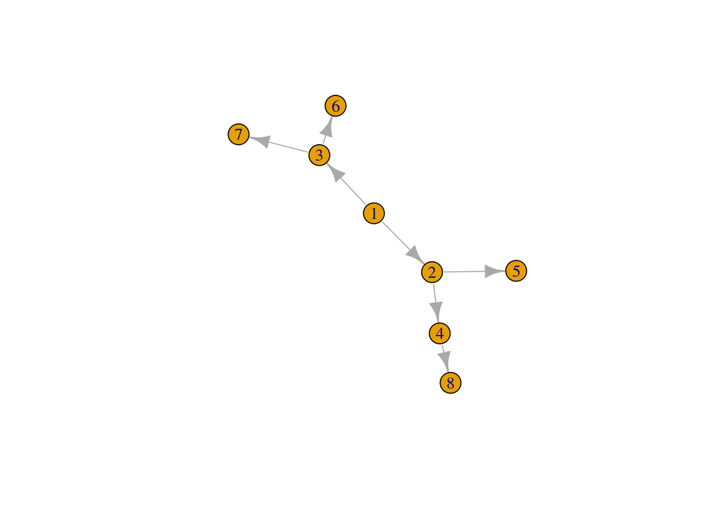

```r
par(mfrow=c(1,1))
# grafo estandar dirigido descendiente (estandar)
plot(graph.tree(8, mode="out"))
```

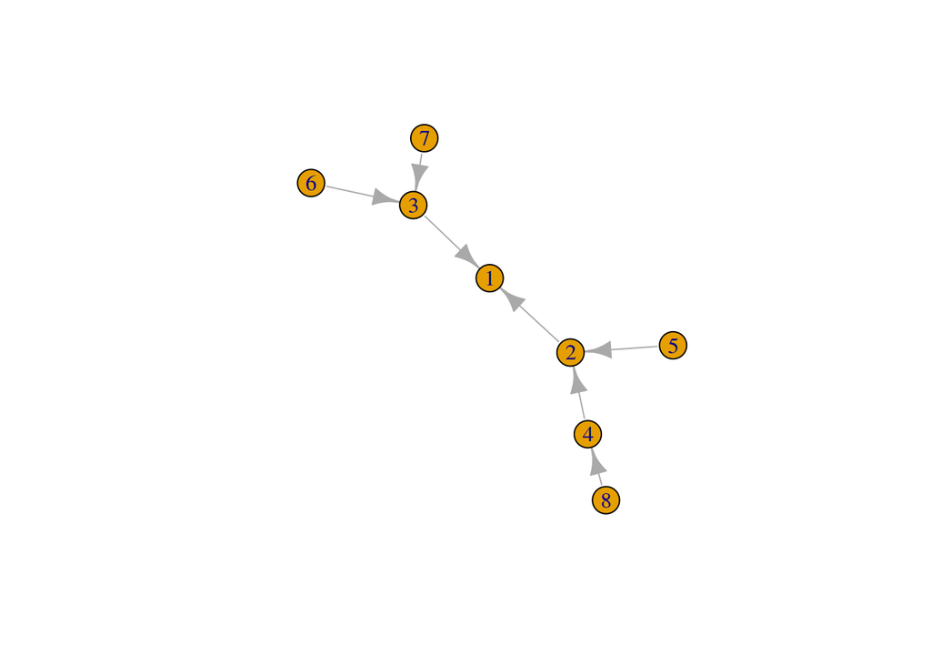

```r
# grafo estandar dirigido progenitor
plot(graph.tree(8, mode="in"))
```

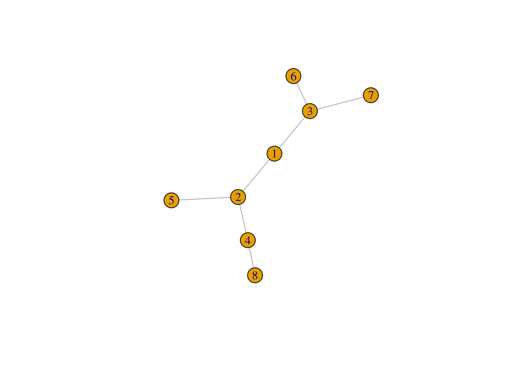

```r
# grafo no dirigido
plot(graph.tree(8, mode="undirected"))
```

**Los grafos descritos hasta ahora satisfacen ciertas condiciones de simetria. A continuacion veremos ejemplos que relajan estas restriciones.**

## 3.5 E5:- `graph`

A traves de `graph` podemos especificar **grafos asimetricos** definidos a partir de una matriz de concectividad dada por un `arreglo`, una `matriz` o un `data.frame`.

Una matriz conectora se define empleando como coordenadas que estan vinculados. Cada nodo corresponde a un reglon o columna. El `primer argumento` de esta funcion proporciona la especificacion de los `nodos` conectados. El `segundo argumento` especifica el tipo de conectividad.

```r
# Grafos en dos dimensiones
g <- graph( c(1,2,
              1,3,
              1,1,
              1,5,
              3,4,
              4,5,
              5,6),
            directed=TRUE )
g
```

```
## IGRAPH d180485 D--- 6 7 --
## + edges from d180485:
## [1] 1->2 1->3 1->1 1->5 3->4 4->5 5->6
```

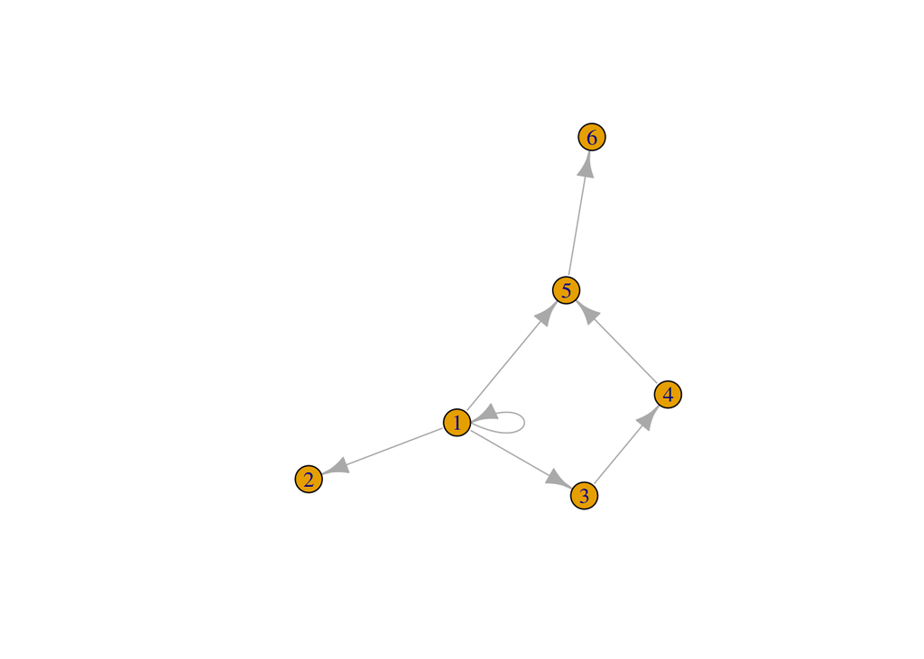

```r
plot(g)
```

Para un `grafo` en particular, podemos emplear la funcion `are.connected` para identificar si estan conectados o no. Si el tipo de `grafo` es dirigido, tomara en cuenta la direccionalidad para identificar el orden de conectividad entre los nodos.

```r
are.connected(g,1,3)
```

```
## [1] TRUE
```

```r
are.connected(g,3,1)
```

```
## [1] FALSE
```

```r
are.connected(g,5,1)
```

```
## [1] FALSE
```

## 3.6 E6:- `graph.full`

Con `graph.full` podemos definir un grafo saturado (i.e. donde todos sus nodos estan conectados entree si). Con la funcion `is.directed` podemos identificar si un `grafo` es dirigido o no.

```r
g <- graph.full(8, directed=TRUE)
g
```

```
## IGRAPH 4b8aba1 D--- 8 56 -- Full graph
## + attr: name (g/c), loops (g/l)
## + edges from 4b8aba1:
##  [1] 1->2 1->3 1->4 1->5 1->6 1->7 1->8 2->1 2->3 2->4 2->5 2->6 2->7 2->8
## [15] 3->1 3->2 3->4 3->5 3->6 3->7 3->8 4->1 4->2 4->3 4->5 4->6 4->7 4->8
## [29] 5->1 5->2 5->3 5->4 5->6 5->7 5->8 6->1 6->2 6->3 6->4 6->5 6->7 6->8
## [43] 7->1 7->2 7->3 7->4 7->5 7->6 7->8 8->1 8->2 8->3 8->4 8->5 8->6 8->7
```

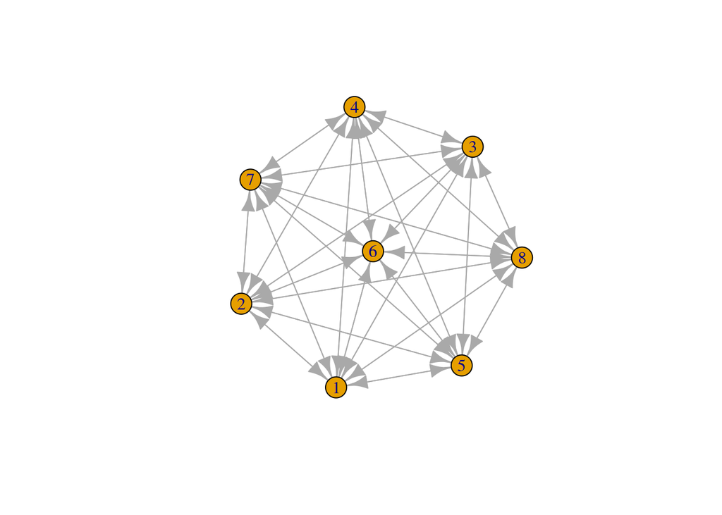

```r
plot(g)
```

```r
is.directed(g)
```

```
## [1] TRUE
```

## 3.7 E7:- `graph`

Este es un ejemplo de un `grafo` separado con componentes de conectividad dirigidos. El parametro `n` representa el numero de `nodo`. Con la funcion `edge.list` recuperamos justamente los nodos que estan conectados de un objeto `grafo`.

```r
g <- graph( c(1,2,
              1,3,
              1,1,
              3,4,
              4,5,
              5,6,
              1,6),
            directed=TRUE,
            n=8 )
g
```

```
## IGRAPH 1fd5a00 D--- 8 7 --
## + edges from 1fd5a00:
## [1] 1->2 1->3 1->1 3->4 4->5 5->6 1->6
```

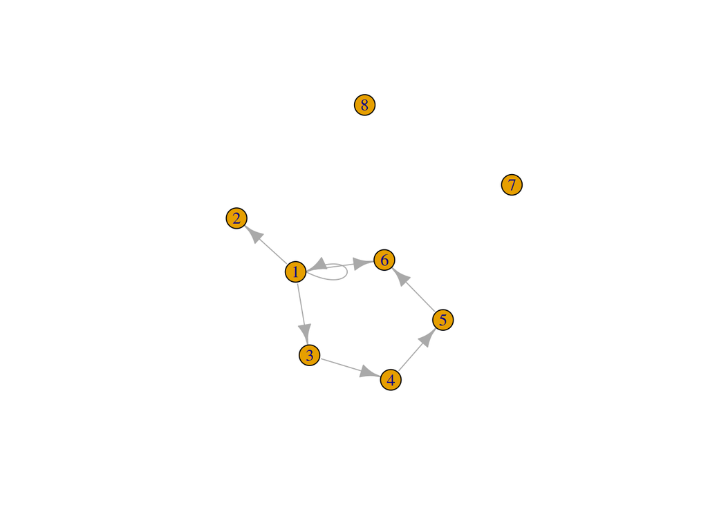

```r
plot(g)
```

```r
is.directed(g)
```

```
## [1] TRUE
```

```r
get.edgelist(g)
```

```
##      [,1] [,2]
## [1,]    1    2
## [2,]    1    3
## [3,]    1    1
## [4,]    3    4
## [5,]    4    5
## [6,]    5    6
## [7,]    1    6
```

## 3.8 E8:- `graph`

En este caso, creamos un grafo a partir de una `matriz` de `nodos` conectados. Definimos `edgelist` como el objeto matriz de conexion.

```r
# Matriz
edgelist <- matrix(c(1:5,3:6,1),
                   ncol=2)
edgelist
```

```
##      [,1] [,2]
## [1,]    1    3
## [2,]    2    4
## [3,]    3    5
## [4,]    4    6
## [5,]    5    1
```

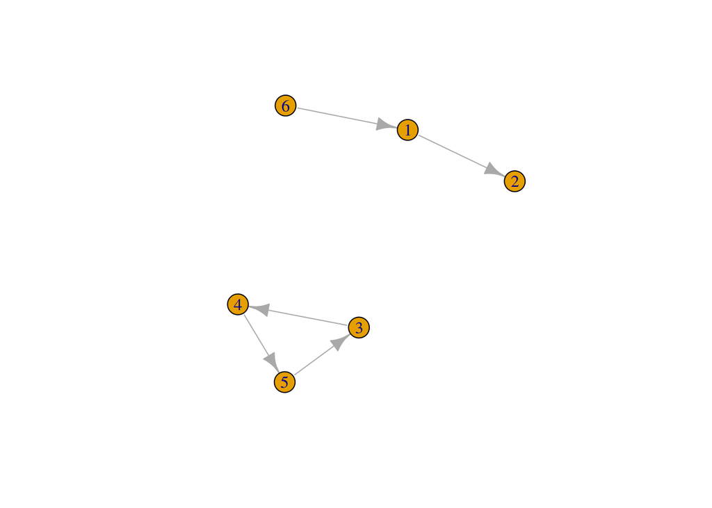

```r
g <- graph(edgelist)
plot(g)
```

## 3.9 E9:- `graph.adjacency`

Definimos ahora un `grafo` a partir una matriz de adyacencia (que es una matrix con entradas dicotomicas indicando si los `nodos` dados coordenada a coordenada en la matriz estan conectados o no).

En este ejemplo definimos una matriz de adyacencia de manera aleatoria.

```r
set.seed(123)
# matrix adyacencia
n <- 8 # numero de nodos
adjacency.matrix <- matrix( (runif(n^2)>.5)+0,
                            nrow=n )
adjacency.matrix
```

```
##      [,1] [,2] [,3] [,4] [,5] [,6] [,7] [,8]
## [1,]    0    1    0    1    1    0    0    0
## [2,]    1    0    0    1    1    0    1    1
## [3,]    0    1    0    1    0    0    0    1
## [4,]    1    0    1    1    0    0    0    0
## [5,]    1    1    1    0    1    0    1    1
## [6,]    0    1    1    0    0    0    0    0
## [7,]    1    0    1    1    0    0    1    0
## [8,]    1    1    1    1    0    0    0    0
```

```r
g <- graph.adjacency(adjacency.matrix)
g
```

```
## IGRAPH e5720d8 D--- 8 30 --
## + edges from e5720d8:
##  [1] 1->2 1->4 1->5 2->1 2->4 2->5 2->7 2->8 3->2 3->4 3->8 4->1 4->3 4->4
## [15] 5->1 5->2 5->3 5->5 5->7 5->8 6->2 6->3 7->1 7->3 7->4 7->7 8->1 8->2
## [29] 8->3 8->4
```

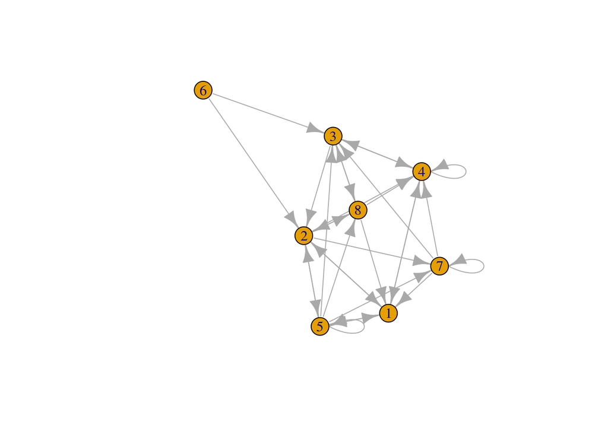

```
## 8 x 8 sparse Matrix of class "dgCMatrix"
##
## [1,] . 1 . 1 1 . . .
## [2,] 1 . . 1 1 . 1 1
## [3,] . 1 . 1 . . . 1
## [4,] 1 . 1 1 . . . .
## [5,] 1 1 1 . 1 . 1 1
## [6,] . 1 1 . . . . .
## [7,] 1 . 1 1 . . 1 .
## [8,] 1 1 1 1 . . . .
```

```r
plot(g)
get.adjacency(g)
```

## 3.10 E10:- `graph`

```r
# Creamos el data frame
n <- 10
df <- data.frame(name = sample(letters[1:10],size=n,replace=TRUE),
                 age = rpois(n,20),
                 gender = sample(c("F","M"),size=n,replace=TRUE))
df
```

```
##    name age gender
## 1     j  15      M
## 2     d  23      F
## 3     e  19      F
## 4     b  17      F
## 5     g  24      M
## 6     j  14      M
## 7     j  17      F
## 8     f  24      M
## 9     e  28      M
## 10    j  22      M
```

```r
lapply(df, class)
```

```
## $name
## [1] "factor"
##
## $age
## [1] "integer"
##
## $gender
## [1] "factor"
```

Desplegamos el `grafo` de conectividad de `g`.

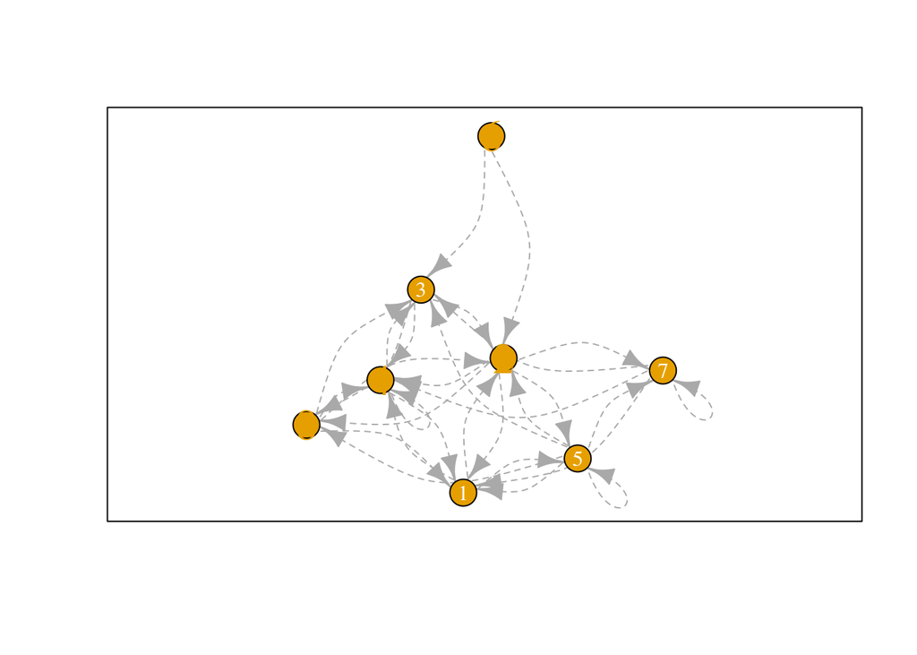

```r
plot.igraph(g, layout=layout.fruchterman.reingold,
            vertex.label.dist=0,
            vertex.label.cex=1:2,
            vertex.label.degree=pi/2,
            vertex.shape=c("circle","circle"),
            vertex.label.color=c(0,1),
            edge.color=E(g)$color,
            edge.width=E(g)$weight,
            edge.label=E(g)$names,
            edge.label.cex=2,
            edge.lty=2,
            edge.curved=TRUE,
            edge.loop.angle=pi/4,
            edge.arrow.size=1,
            frame=TRUE)
```

# 4 Lecturas complementarias

- **Lauritzen** - Graphical Models
- **Koller y Firiedman** - Probabilistic Graphical Models Principles and Techniques
- **Hoejsgaard et al** - Graphical models in R